# Getting Started with fmrilss

fmrilss Development Team

2025-11-01

## The Challenge of Event-Related fMRI Analysis

In event-related fMRI experiments with rapid stimulus presentation, hemodynamic responses from consecutive trials overlap substantially due to the slow temporal dynamics of the BOLD signal (10-15 seconds). Traditional general linear models (GLMs) that estimate all trials simultaneously suffer from collinearity when inter-stimulus intervals are short (< 4 seconds), resulting in unstable trial-specific activation estimates. These unstable estimates compromise downstream analyses including multivariate pattern analysis (MVPA), representational similarity analysis (RSA), and trial-by-trial connectivity methods.

The Least Squares Separate (LSS) approach (Mumford et al., 2012) addresses this collinearity problem by fitting a separate GLM for each trial. In each model, one regressor represents the trial of interest while a second regressor aggregates all other trials, reducing collinearity and improving estimate stability. The `fmrilss` package provides optimized implementations of LSS with extensions including automatic HRF estimation, ridge regularization, and parallel computation across multiple CPU cores.

## Understanding the LSS Approach

This vignette assumes familiarity with fMRI general linear models, design matrices, hemodynamic response functions, and R matrix operations.

Standard GLM analysis (Least Squares All, LSA) estimates all trial coefficients simultaneously by solving:

$$\boldsymbol{\beta} =
(\mathbf{X}'\mathbf{X})^{-1}\mathbf{X}'\mathbf{Y}$$

When trials occur in rapid succession, the design matrix columns exhibit high correlation (condition number > 30), producing unstable trial estimates with inflated variance.

LSS reformulates the problem by fitting $N$ separate models, where $N$ is the number of trials. For trial $i$, the design matrix contains: (1) a regressor for trial $i$, (2) a single regressor aggregating all other trials, and (3) any nuisance or baseline regressors. This reduces the effective condition number and produces more stable single-trial estimates. Mathematically, for trial $i$:

$$\boldsymbol{\beta}_i =
(\mathbf{X}_i'\mathbf{X}_i)^{-1}\mathbf{X}_i'\mathbf{Y}$$

where $\mathbf{X}_i = [\mathbf{x}_i \mid \sum_{j \neq i} \mathbf{x}_j \mid \mathbf{Z} \mid \mathbf{N}]$, with $\mathbf{x}_i$ the trial regressor, $\mathbf{Z}$ experimental covariates, and $\mathbf{N}$ nuisance regressors.

Beyond these two core regressors, LSS models can include experimental regressors that capture session-wide effects like linear trends or block effects, which we want to model but don’t need trial-specific estimates for. The model can also incorporate nuisance regressors such as motion parameters or physiological noise, which are projected out before the analysis begins.

## Your First LSS Analysis

```r
library(fmrihrf)
library(fmrilss)

set.seed(42)
n_timepoints <- 150
n_trials <- 12
n_voxels <- 25
```

The following example demonstrates LSS analysis using synthetic data from a rapid event-related design.

### Creating the Experimental Design

The design matrix encodes stimulus timing and expected hemodynamic responses. When available, we recommend building event‑related designs with fmridesign::event_model(), which cleanly specifies HRF bases, blocks/runs, and parametric modulators. We include a backward‑compatible fallback if the package is not installed.

```r
# Define sampling frame and trial onsets (in TRs)
sframe <- fmrihrf::sampling_frame(blocklens = n_timepoints, TR = 1)
# Spread trials across the run but induce overlap with jitter
bounds <- c(10L, n_timepoints - 24L)
base_onsets <- round(seq(from = bounds[1], to = bounds[2], length.out = n_trials))
set.seed(42)
# Slightly more overlap via larger jitter window (±3 TR)
jitter <- sample.int(7, n_trials, replace = TRUE) - 4L  # -3..+3 TR
onsets <- sort(pmax(bounds[1], pmin(base_onsets + jitter, bounds[2])))

if (requireNamespace("fmridesign", quietly = TRUE)) {
  # Build one HRF column per trial directly with fmridesign
  des <- data.frame(onset = onsets, run = 1, trial = factor(seq_len(n_trials)))
  hrf <- fmridesign::hrf  # bind symbol for formula
  emod <- fmridesign::event_model(
    onset ~ hrf(trial, basis = "spmg1"),
    data = des, block = ~run, sampling_frame = sframe, precision = 0.1
  )
  X <- fmridesign::design_matrix(emod)
  # Ensure numeric matrix downstream
  if (inherits(X, "Matrix")) X <- as.matrix(X)
  if (!is.matrix(X)) X <- as.matrix(X)
} else {
  # Fallback: simple HRF‑convolved design using a gamma kernel (one column per trial)
  simple_hrf <- function(t) ifelse(t >= 0, dgamma(t, shape = 6, rate = 1), 0)
  X <- matrix(0, n_timepoints, n_trials)
  hrf_kernel <- simple_hrf(0:20)  # HRF spanning ~20 TRs
  for (i in seq_len(n_trials)) {
    onset <- onsets[i]
    hrf_length <- min(length(hrf_kernel), n_timepoints - onset + 1)
    X[onset:(onset + hrf_length - 1), i] <- hrf_kernel[1:hrf_length]
  }
}

# Ensure downstream dimensions use the actual number of trial columns in X
n_trials_eff <- ncol(X)

# Experimental regressors (Z) — intercept and linear trend
# These are regressors we want to model but not trial‑wise
Z <- cbind(Intercept = 1, LinearTrend = as.vector(scale(1:n_timepoints, center = TRUE, scale = FALSE)))

# Nuisance regressors — e.g., 6 motion parameters
Nuisance <- matrix(rnorm(n_timepoints * 6), n_timepoints, 6)
```

Matrix `X` contains HRF-convolved trial regressors. Matrix `Z` contains experimental covariates (intercept and linear trend). The nuisance matrix models unwanted variance (e.g., motion parameters).

### Visualizing Regressors

The following visualizations show experimental regressors (excluding intercept) and nuisance regressors, standardized for comparability.

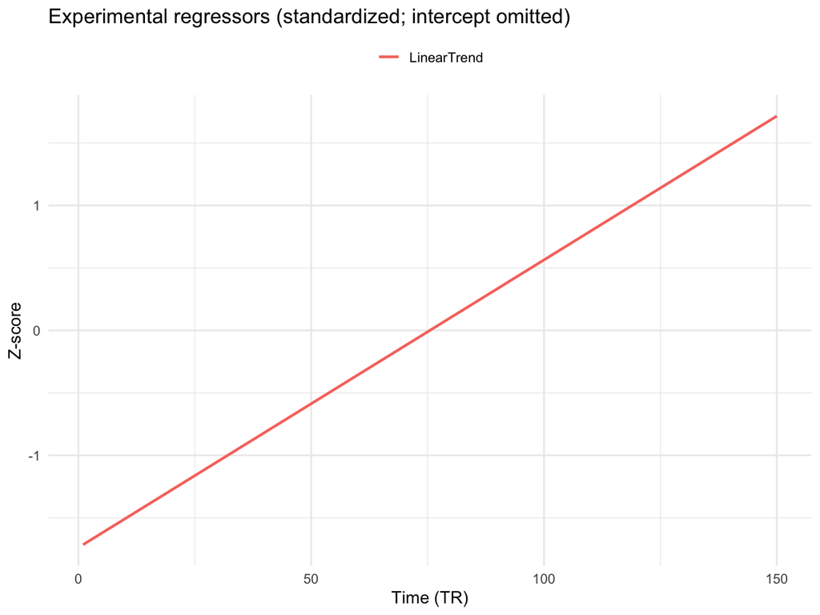

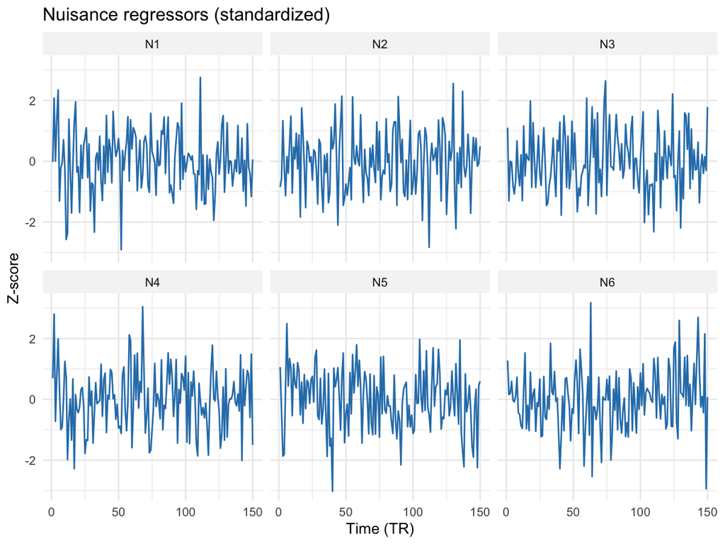

### Single-Trial Regressors

Trial regressor structure visualized as a time x trial heatmap:

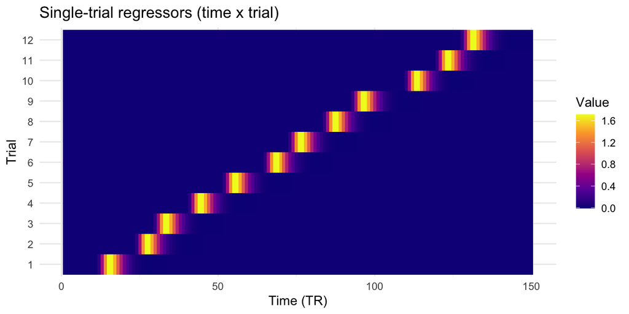

### Generating Realistic Data

Now we’ll create synthetic fMRI data that includes contributions from all these components, plus some noise to make it realistic:

```r
# Simulate effects for each component
true_trial_betas <- matrix(rnorm(n_trials_eff * n_voxels, 0, 1.2), n_trials_eff, n_voxels)
true_fixed_effects <- matrix(rnorm(2 * n_voxels, c(5, -0.1), 0.5), 2, n_voxels)
true_nuisance_effects <- matrix(rnorm(6 * n_voxels, 0, 2), 6, n_voxels)

# Combine signals and add noise
Y <- (Z %*% true_fixed_effects) +
     (X %*% true_trial_betas) +
     (Nuisance %*% true_nuisance_effects) +
     matrix(rnorm(n_timepoints * n_voxels, 0, 1), n_timepoints, n_voxels)
```

### Running the Analysis

The `lss()` function provides a clean, modern interface that adapts to your needs. At its simplest, you can provide just the data and trial matrix, and the function automatically includes an intercept term:

```r
beta_basic <- lss(Y, X)
# The result is a trials-by-voxels matrix
dim(beta_basic)
```

```
#> [1] 12 25
```

For a more complete analysis that accounts for experimental effects and removes nuisance signals, we include our `Z` and `Nuisance` matrices. The function handles the nuisance regression efficiently, projecting these signals out of both the data and design matrix before estimating trial-specific betas:

```r
beta_full <- lss(Y, X, Z = Z, Nuisance = Nuisance)
# The output dimensions remain the same
dim(beta_full)
```

```
#> [1] 12 25
```

## Handling Temporal Autocorrelation with Prewhitening

fMRI time series exhibit temporal autocorrelation that can affect statistical inference. The `fmrilss` package now integrates with `fmriAR` to provide sophisticated prewhitening capabilities:

```r
# Basic AR(1) prewhitening
beta_ar1 <- lss(Y, X, Z = Z, Nuisance = Nuisance,
                prewhiten = list(method = "ar", p = 1))

# Automatic AR order selection
beta_auto <- lss(Y, X, Z = Z, Nuisance = Nuisance,
                prewhiten = list(method = "ar", p = "auto", p_max = 4))

# The prewhitened estimates account for temporal dependencies
dim(beta_ar1)
```

```
#> [1] 12 25
```

For more advanced noise modeling, you can use voxel-specific parameters or ARMA models:

```r
# Voxel-specific AR parameters (slower but more accurate)
# Default pooling="global" estimates one AR model across all voxels
# pooling="voxel" fits separate AR models per voxel (~100x slower)
beta_voxel <- lss(Y, X, Z = Z, Nuisance = Nuisance,
                  prewhiten = list(method = "ar", p = 1, pooling = "voxel"))

# ARMA model for complex noise (AR + moving average components)
# Use when residuals show both autocorrelation and moving average patterns
beta_arma <- lss(Y, X, Z = Z, Nuisance = Nuisance,
                prewhiten = list(method = "arma", p = 2, q = 1))
```

**Pooling strategies:** - `pooling = "global"` (default): Single AR model for all voxels (fast) - `pooling = "voxel"`: Per-voxel AR models (accurate but slow) - `pooling = "run"`: Separate model per run (for multi-run data)

## Choosing the Right Computational Backend

The `fmrilss` package offers multiple computational backends, each optimized for different scenarios. While the default R implementation is well-optimized and readable, making it excellent for understanding the algorithm and debugging, you’ll often want to use the high-performance C++ backend for real analyses, especially with large datasets. The C++ implementation leverages Armadillo for efficient linear algebra and OpenMP for parallel processing across multiple CPU cores:

```r
# Run the same analysis with the high-performance C++ engine
beta_fast <- lss(Y, X, Z = Z, Nuisance = Nuisance, method = "cpp_optimized")

# The results are numerically identical to the R version
all.equal(beta_full, beta_fast, tolerance = 1e-8)
```

```
#> [1] TRUE
```

```r
# Combine prewhitening with fast computation
beta_fast_ar <- lss(Y, X, Z = Z, Nuisance = Nuisance,
                    method = "cpp_optimized",
                    prewhiten = list(method = "ar", p = 1))
```

This modular design allows seamless switching between backends without code changes. The R implementation facilitates debugging and development, while the C++ version provides production performance.

### Visualizing the Trial Design

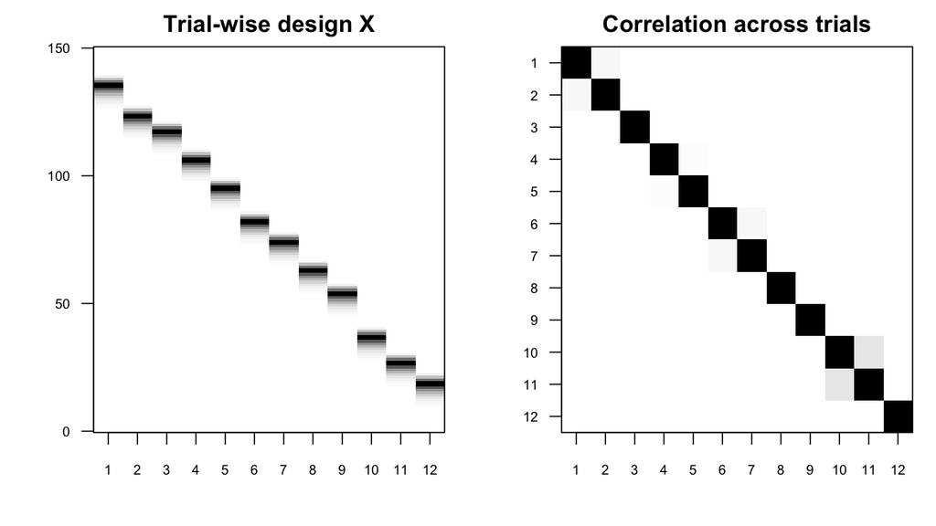

```r
par(mfrow = c(1, 2), mar = c(4, 4, 2, 1))

# Heatmap of X (time x trials)
image(t(X[nrow(X):1, , drop = FALSE]), axes = FALSE,
      main = "Trial-wise design X",
      col = gray.colors(64, start = 1, end = 0))
axis(1, at = seq(0, 1, length.out = ncol(X)), labels = seq_len(ncol(X)), cex.axis = 0.7)
lab_y <- pretty(1:nrow(X), n = 5)
axis(2, at = seq(0, 1, length.out = length(lab_y)), labels = lab_y, las = 1, cex.axis = 0.7)
box()

# Column correlation matrix
CX <- suppressWarnings(cor(X))
image(CX[ncol(X):1, , drop = FALSE], axes = FALSE,
      main = "Correlation across trials",
      col = gray.colors(64, start = 1, end = 0))
axis(1, at = seq(0, 1, length.out = ncol(X)), labels = seq_len(ncol(X)), cex.axis = 0.7)
axis(2, at = seq(0, 1, length.out = ncol(X)), labels = rev(seq_len(ncol(X))), las = 1, cex.axis = 0.7)
box()
```

```r
# Report a simple conditioning summary
sv <- svd(X, nu = 0, nv = 0)$d
cond_num <- if (length(sv) > 1) max(sv) / max(min(sv), .Machine$double.eps) else 1
cat(sprintf("\nDesign summary: trials = %d, condition number ≈ %.1f\n", ncol(X), cond_num))
```

```
#>
#> Design summary: trials = 12, condition number ≈ 1.2
```

## LSS versus Traditional GLM: When Each Shines

Comparison between LSS and standard Least Squares All (LSA) methods. LSA is the traditional GLM approach that estimates all trial coefficients simultaneously in a single model, making it computationally faster but more susceptible to collinearity in rapid designs.

```r
# LSA: Standard GLM (Least Squares All) estimates all trials simultaneously
# This is computationally faster but suffers from collinearity in rapid designs
beta_lsa <- lsa(Y, X, Z = Z, Nuisance = Nuisance)

# Compare dimensions
cat("LSS beta dimensions:", dim(beta_full), "\n")
```

```
#> LSS beta dimensions: 12 25
```

```r
cat("LSA beta dimensions:", dim(beta_lsa), "\n")
```

```
#> LSA beta dimensions: 12 25
```

```r
# Compare variance in beta estimates
var_lss <- apply(beta_full, 2, var)
var_lsa <- apply(beta_lsa, 2, var)

cat("\nMean variance across voxels:\n")
```

```
#>
#> Mean variance across voxels:
```

```r
cat("  LSS:", mean(var_lss), "\n")
```

```
#>   LSS: 1.67553
```

```r
cat("  LSA:", mean(var_lsa), "\n")
```

```
#>   LSA: 3.265106
```

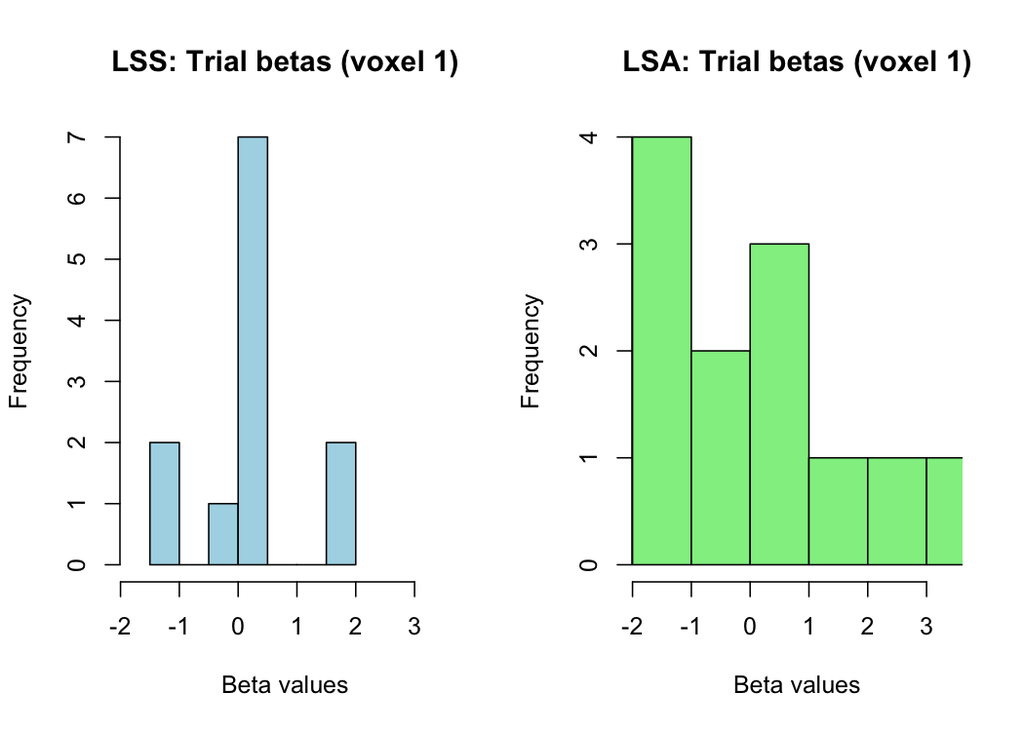

```r
# Plot comparison (single voxel example; same x-range for both histograms)
par(mfrow = c(1, 2))
v <- 1L
xlim1 <- range(c(beta_full[, v], beta_lsa[, v]))
hist(beta_full[, v], main = "LSS: Trial betas (voxel 1)",
     xlab = "Beta values", col = "lightblue", xlim = xlim1)
hist(beta_lsa[, v], main = "LSA: Trial betas (voxel 1)",
     xlab = "Beta values", col = "lightgreen", xlim = xlim1)
```

### Scatter: LSS vs LSA (shrinkage visualization)

The scatter below compares trial-wise betas from LSS (y-axis) against LSA (x-axis). The dashed gray line shows identity; the red line is an LM fit through the origin (LSS ~ LSA). With greater temporal overlap, LSS typically shows mild shrinkage relative to LSA.

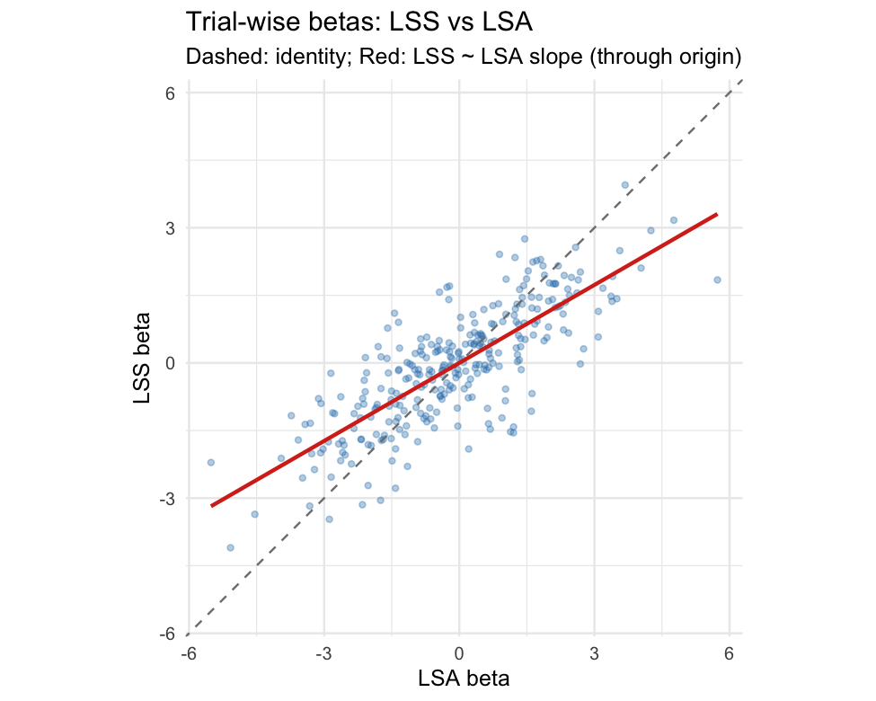

```r
df_sc <- data.frame(LSA = as.vector(beta_lsa), LSS = as.vector(beta_full))
if (requireNamespace("ggplot2", quietly = TRUE)) {
  rng <- range(df_sc$LSA, df_sc$LSS)
  ggplot2::ggplot(df_sc, ggplot2::aes(LSA, LSS)) +
    ggplot2::geom_point(alpha = 0.35, size = 1.2, color = "#2c7fb8") +
    ggplot2::geom_abline(slope = 1, intercept = 0, linetype = "dashed", color = "gray50") +
    ggplot2::geom_smooth(method = "lm", formula = y ~ 0 + x, se = FALSE,
                         color = "#d7301f", linewidth = 1) +
    ggplot2::coord_equal(xlim = rng, ylim = rng) +
    ggplot2::labs(title = "Trial-wise betas: LSS vs LSA",
                  subtitle = "Dashed: identity; Red: LSS ~ LSA slope (through origin)",
                  x = "LSA beta", y = "LSS beta") +
    ggplot2::theme_minimal(base_size = 12)
} else {
  op <- par(no.readonly = TRUE); on.exit(par(op), add = TRUE)
  plot(df_sc$LSA, df_sc$LSS, pch = 19, col = rgb(0.17, 0.5, 0.72, 0.35),
       xlab = "LSA beta", ylab = "LSS beta", main = "Trial-wise betas: LSS vs LSA")
  abline(0, 1, lty = 2, col = "gray50")
  coef1 <- coef(lm(LSS ~ 0 + LSA, data = df_sc))[1]
  abline(0, coef1, col = "#d7301f", lwd = 2)
}
```

LSS produces beta estimates with different variance characteristics than LSA. Method selection criteria:

**Use LSS for:** - MVPA and pattern classification analyses - Rapid event-related designs (ISI < 4 seconds) - Trial-by-trial connectivity analyses - Representational similarity analysis (RSA)

**Use LSA for:** - Block designs with well-separated trials - Group-level contrast estimation - Designs with ISI > 6 seconds - When computational efficiency is critical

## Introducing the OASIS Method

The OASIS (Optimized Analytic Single-pass Inverse Solution) method extends LSS with: automatic HRF estimation, ridge regularization for stability, single-pass computation for all trials, and multi-basis HRF model support.

```r
# Basic OASIS usage with automatic design construction
# fmrihrf is now imported automatically
beta_oasis <- lss(
  Y = Y,
  X = NULL,  # Let OASIS build design from design_spec
  method = "oasis",
  oasis = list(
    design_spec = list(
      sframe = sampling_frame(blocklens = nrow(Y), TR = 1),
      cond = list(
        onsets = onsets,        # reuse onsets from above
        hrf = HRF_SPMG1,        # SPM canonical HRF
        span = 30               # HRF duration in seconds
      )
    ),
    ridge_mode = "fractional",  # Regularization for numerical stability
    ridge_x = 0.01,             # Ridge for design matrix
    ridge_b = 0.01              # Ridge for coefficients
  )
)

cat("OASIS beta dimensions:", dim(beta_oasis), "\n")
```

```
#> OASIS beta dimensions: 12 25
```

```r
# Alternative: Provide a pre-built design matrix directly
# beta_oasis_manual <- lss(Y, X = my_hrf_convolved_design, method = "oasis", ...)
```

**Why `X = NULL`?** OASIS can build the design matrix internally from `design_spec`, ensuring the HRF settings stay synchronized with the design. This is especially useful when exploring different HRFs or using multi-basis models. Alternatively, you can provide your own HRF-convolved design via `X`.

## Working with Different Computational Backends

The package provides multiple backends to match your computational needs and resources. Each backend implements the same algorithm but with different optimization strategies. The `naive` implementation offers the clearest code for understanding the algorithm, while `r_vectorized` and `r_optimized` provide good performance with pure R code. For production work with large datasets, `cpp_optimized` offers the best performance, especially when combined with parallel processing.

```r
# Benchmark different methods
library(microbenchmark)

methods <- c("naive", "r_vectorized", "r_optimized", "cpp_optimized")
timings <- list()

for (m in methods) {
  timings[[m]] <- system.time({
    lss(Y, X, method = m)
  })[3]
}

# Display timing comparison
timing_df <- data.frame(
  Method = methods,
  Time = unlist(timings)
)
print(timing_df)

# For large datasets, consider threading for C++ backends
if (require("parallel")) {
  n_cores <- parallel::detectCores() - 1
  # Set OpenMP threads for C++ backend if supported
  Sys.setenv(OMP_NUM_THREADS = n_cores)
}
```

## Handling Complex Experimental Designs

Real experiments often involve multiple conditions, parametric modulations, and various covariates. The `fmrilss` package handles these complexities gracefully. When working with multiple conditions, you can create separate design matrices for each condition and include condition labels as experimental regressors. This allows you to model condition-specific effects while still obtaining trial-wise estimates within each condition.

```r
# Create design with multiple conditions
n_cond <- 3
X_multi <- matrix(0, n_timepoints, n_trials * n_cond)

# Generate a simple HRF for demonstration
hrf <- c(0, 0.2, 0.5, 0.8, 1, 0.9, 0.7, 0.5, 0.3, 0.1)

for (c in 1:n_cond) {
  trial_idx <- ((c-1) * n_trials + 1):(c * n_trials)
  for (i in 1:n_trials) {
    onset <- 10 + (trial_idx[i] - 1) * 5
    if (onset + 9 <= n_timepoints) {
      X_multi[onset:(onset + 9), trial_idx[i]] <- hrf
    }
  }
}

# Add condition labels as experimental regressors
Z_cond <- matrix(0, n_timepoints, n_cond)
for (c in 1:n_cond) {
  trial_idx <- ((c-1) * n_trials + 1):(c * n_trials)
  Z_cond[, c] <- rowSums(X_multi[, trial_idx, drop = FALSE])
}

# Run LSS with condition regressors
beta_multi <- lss(Y, X_multi, Z = Z_cond, method = "r_optimized")
```

Parametric modulations, where trial responses are weighted by continuous variables like reaction time or stimulus intensity, are also straightforward to implement. For a quantitative demo, we simulate a parametric effect in the data and show recovery with and without the modulator:

```r
# Add parametric modulator (e.g., reaction time, stimulus intensity)
modulator <- scale(rnorm(n_trials, mean = 0, sd = 1), center = TRUE, scale = FALSE)

# Create parametrically modulated design (scale each trial by its modulator)
X_param <- sweep(X, 2, as.numeric(modulator), `*`)

# Simulate data with a parametric effect (reuse fixed and nuisance parts)
Y_mod <- (Z %*% true_fixed_effects) +
         (X_param %*% true_trial_betas) +
         (Nuisance %*% true_nuisance_effects) +
         matrix(rnorm(n_timepoints * n_voxels, 0, 1), n_timepoints, n_voxels)

# Fit models with and without the parametric modulator
beta_unmod <- lss(Y_mod, X,       Z = Z, method = "r_optimized")
beta_param <- lss(Y_mod, X_param, Z = Z, method = "r_optimized")

# Ground truth depends on which design matrix we use:
# - When fitting with X (unmodulated):        recovers modulator * true_trial_betas
# - When fitting with X_param (premodulated): recovers true_trial_betas directly
true_unmod_coefs <- sweep(true_trial_betas, 1, as.numeric(modulator), `*`)

cor_unmod <- cor(as.vector(beta_unmod), as.vector(true_unmod_coefs))
cor_param <- cor(as.vector(beta_param), as.vector(true_trial_betas))

cat("Correlation with true coefficients (parametric effect simulated):\n")
```

```
#> Correlation with true coefficients (parametric effect simulated):
```

```r
cat("  Using X (no modulator):\t", round(cor_unmod, 3), "\n")
```

```
#>   Using X (no modulator):     0.625
```

```r
cat("  Using X_param (with modulator):", round(cor_param, 3), "\n")
```

```
#>   Using X_param (with modulator): 0.109
```

## Optimizing Performance for Large-Scale Analyses

When working with whole-brain data containing hundreds of thousands of voxels, memory management and computational efficiency become critical. The package provides several strategies for handling large datasets effectively.

For very large datasets that exceed available memory, you can process voxels in chunks. This approach maintains reasonable memory usage while still benefiting from vectorized operations within each chunk:

```r
# For very large datasets, process in chunks
chunk_size <- 1000
n_chunks <- ceiling(ncol(Y) / chunk_size)

beta_chunks <- list()
for (chunk in 1:n_chunks) {
  voxel_idx <- ((chunk - 1) * chunk_size + 1):min(chunk * chunk_size, ncol(Y))
  beta_chunks[[chunk]] <- lss(Y[, voxel_idx], X, method = "cpp_optimized")
}

# Combine results
beta_full <- do.call(cbind, beta_chunks)
```

Another optimization strategy involves preprocessing your data to remove nuisance signals before running LSS. While LSS can handle nuisance regressors internally, preprocessing can be more efficient when running multiple analyses:

```r
# Project out nuisance before LSS (when appropriate)
# project_confounds returns the projection matrix Q; apply it to both Y and X
Q_nuis <- project_confounds(Nuisance)
Y_clean <- Q_nuis %*% Y
X_clean <- Q_nuis %*% X

# This can be faster than including Nuisance in each LSS iteration
beta_preprocessed <- lss(Y_clean, X_clean, Z = Z, method = "r_optimized")
```

Choosing the right backend for your data size is crucial for optimal performance:

**Performance guidelines (based on benchmarks):**

| Data Size | Recommended Method | Rationale |
| --- | --- | --- |
| n_trials < 50, n_voxels < 5,000 | `r_optimized` or `cpp_optimized` | Similar speed, R easier to debug |
| n_voxels > 10,000 | `cpp_optimized` | Benefits from OpenMP parallelization |
| Need HRF grid search or ridge | `oasis` | Additional features justify overhead |
| Quick prototyping | `r_optimized` | Good balance of speed and readability |

In practice, pick the backend that matches your needs: R for debugging, C++ for maximum throughput, OASIS for HRF-aware workflows. Always validate with a quick benchmark on your own data.

## Troubleshooting Common Challenges

Even with robust implementations, certain data characteristics can cause issues. Understanding how to diagnose and address these problems will help you get the most out of your analyses.

When design matrices become singular or near-singular due to high collinearity between regressors, standard least squares solutions become unstable. You can detect this by examining the correlation matrix of your design:

```r
# Check for collinearity in design matrix
cor_matrix <- cor(X)
high_cor <- which(abs(cor_matrix) > 0.9 & cor_matrix != 1, arr.ind = TRUE)

if (nrow(high_cor) > 0) {
  warning("High correlation between regressors detected")

  # Option 1: Use OASIS with ridge and automatic design construction
  beta_ridge <- lss(
    Y = Y,
    X = NULL,  # Let OASIS build design
    method = "oasis",
    oasis = list(
      design_spec = list(
        sframe = sampling_frame(blocklens = nrow(Y), TR = 1),
        cond = list(onsets = onsets, hrf = HRF_SPMG1, span = 30)
      ),
      ridge_mode = "absolute",
      ridge_x = 0.1  # Stronger ridge for collinearity
    )
  )

  # Option 2: For standard LSS without OASIS, increase ISI or use prewhitening
  # Ridge is not directly available for non-OASIS backends
}
```

Memory limitations can also pose challenges with large datasets. Before starting an analysis, it’s wise to estimate memory requirements and adjust your approach accordingly:

```r
# Estimate peak memory requirements
mem_Y <- object.size(Y)
mem_designs_approx <- mem_Y * n_trials  # n_trials copies of design during LSS
mem_results <- mem_Y  # Output size similar to Y
mem_required <- mem_Y + mem_designs_approx + mem_results

cat("Estimated memory needed:", round(mem_required / 1e9, 2), "GB\n")

# If this exceeds available RAM, use chunking approach (see example above)
# Or consider OASIS which has lower memory overhead for large datasets
```

If you encounter unexpectedly slow performance, profiling can help identify bottlenecks:

```r
# Profile code to find bottlenecks
Rprof("lss_profile.out")
beta_slow <- lss(Y, X, method = "naive")
Rprof(NULL)
summaryRprof("lss_profile.out")
```

## Where to Go From Here

This vignette has introduced you to the core concepts and capabilities of the `fmrilss` package. You’ve learned how LSS addresses the collinearity problem in rapid event-related designs, how to choose between different computational backends, and strategies for handling complex experimental designs and large datasets.

To deepen your understanding and explore advanced features, we recommend:

- **Voxel-wise HRF vignette**: Model spatial variation in hemodynamic responses across the brain using fully flexible HRF estimation
- **SBHM vignette**: Learn efficient voxel-specific HRF estimation using Shared-Basis HRF Matching, a library-constrained approach that balances flexibility and computational efficiency
- **OASIS method vignette**: Comprehensive coverage of OASIS features including automatic HRF construction, ridge regularization, and multi-basis models
- **Mixed models vignette**: Combine LSS with mixed-effects modeling frameworks for hierarchical analyses

The `fmrilss` package represents a comprehensive toolkit for trial-wise beta estimation, providing options that range from simple, interpretable implementations to highly optimized solutions for large-scale analyses. Whether you’re conducting exploratory analyses on a laptop or processing massive datasets on a computing cluster, the package offers the flexibility and performance you need for modern fMRI analysis.

## References

Mumford, J. A., Turner, B. O., Ashby, F. G., & Poldrack, R. A. (2012). Deconvolving BOLD activation in event-related designs for multivoxel pattern classification analyses. *NeuroImage*, 59(3), 2636-2643.